# Time series

Robert Tarasevic

2020-04-06

```r
library("tidyverse")
library("caret")
library("dplyr")
library("rhdf5")
library("zoo")
library("knitr")
library("mgcv")
```

## Load data

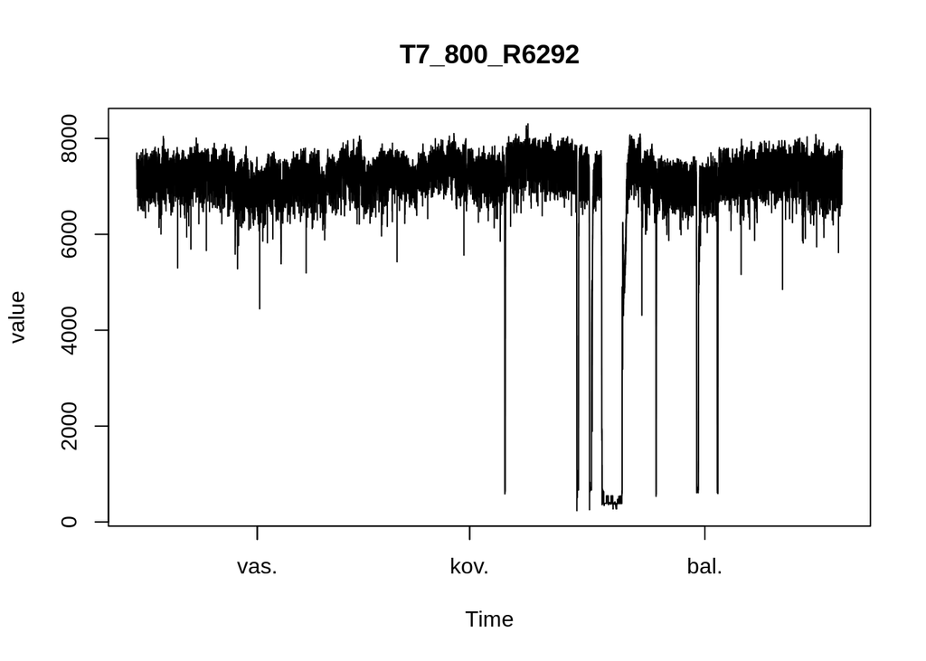

```
## [1] "Only one graph showed because same sensor chosen"
```

## Chosen time period for signals

```
## First signal subset:  2019-02-16 14:55:00 - 2019-02-16 19:50:00
```

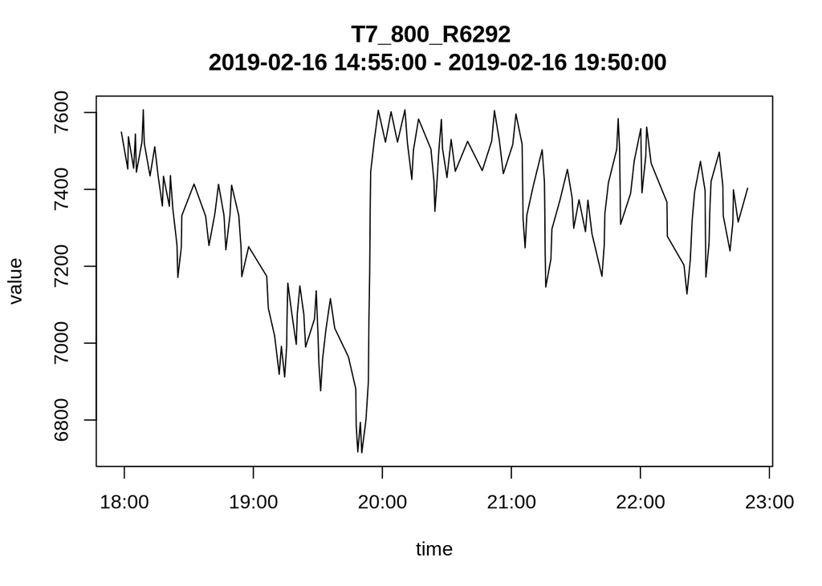

```
## Second signal subset:  2019-02-16 19:50:00 - 2019-02-17 01:02:00
```

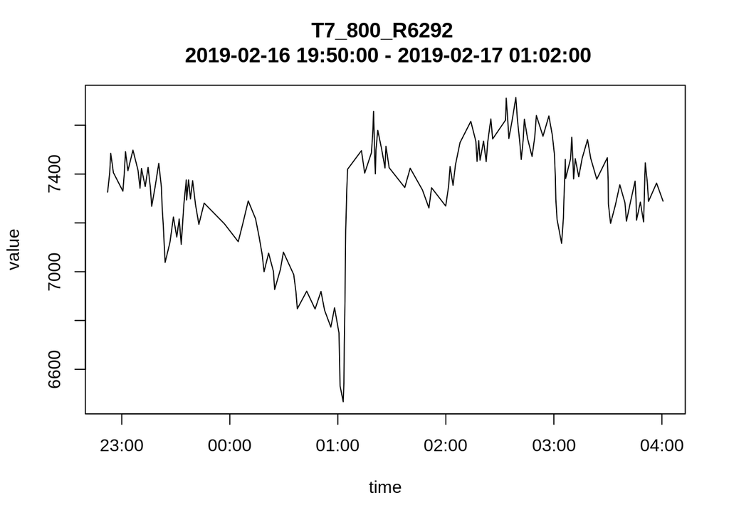

## Statistics table

Statistics table

|  | signal_length | Time_mode | Value_mode | sd | mean | n5 | n25 | n75 | n95 | kurtosis | skewness | rms | entropy | cf | sf | mean_crossing |
| --- | --- | --- | --- | --- | --- | --- | --- | --- | --- | --- | --- | --- | --- | --- | --- | --- |
| subset 1 | 160 | 28 | 7332 | 206.86 | 7310.76 | 6911.45 | 7178.5 | 7457.5 | 7582.05 | 0.04 | -0.84 | 7310.76 | 5.07 | 1.04 | 1.00 | 26 |
| subset 2 | 170 | 12 | 7404 | 250.48 | 7300.81 | 6786.95 | 7199.5 | 7464.0 | 7624.55 | 1.07 | -1.12 | 7300.81 | 5.14 | 1.06 | 1.00 | 25 |
| raw signal 1 | 115711 | 4 | 384 | 2055.88 | 6472.54 | 535.00 | 6894.0 | 7389.0 | 7667.00 | 4.08 | -2.40 | 6472.54 | 11.58 | 1.22 | 1.05 | 698 |
| raw signal 2 | 115711 | 4 | 384 | 2055.88 | 6472.54 | 535.00 | 6894.0 | 7389.0 | 7667.00 | 4.08 | -2.40 | 6472.54 | 11.58 | 1.22 | 1.05 | 698 |

### Some statistics explained:

**Signal length -** *Data points number in signal*  
**Time mode -** *Mode of time change frequency*  
**Value mode -** *Most frequent value*  
**Sd -** *Standard deviation*  
**Mean -** *Average value*  
**n5, n25, n75, n95 -** *Quantile values*  
**Kurtosis -** *Kurtosis quantifies the peak value of the PDF (positive kurtosis tells that there is lot of data in tails, negative - little data in tails*  
**Skewness -** *Skewness quantifies the asymmetry behavior of vibration signal through its PDF*  
**RMS -** *Root mean square value changes faster then mean*  
**Entropy -** *Amount of uncertainty in an entire probability distribution*  
**Crest factor (cf) -** *Ratio of the instantaneous peak amplitude of a waveform, to its root mean square RMS value*  
**Shape factor (sf) -** *Shape factor is a value that is affected by an object’s shape but is independent of its dimensions*  
**Mean crossing -** *Mean value crossing count*

## Correlation

**Correlation between sub-sets**

```
## [1] 0.6683277
```

**Correlation between signals**

```
## [1] 1
```

## Data discretization

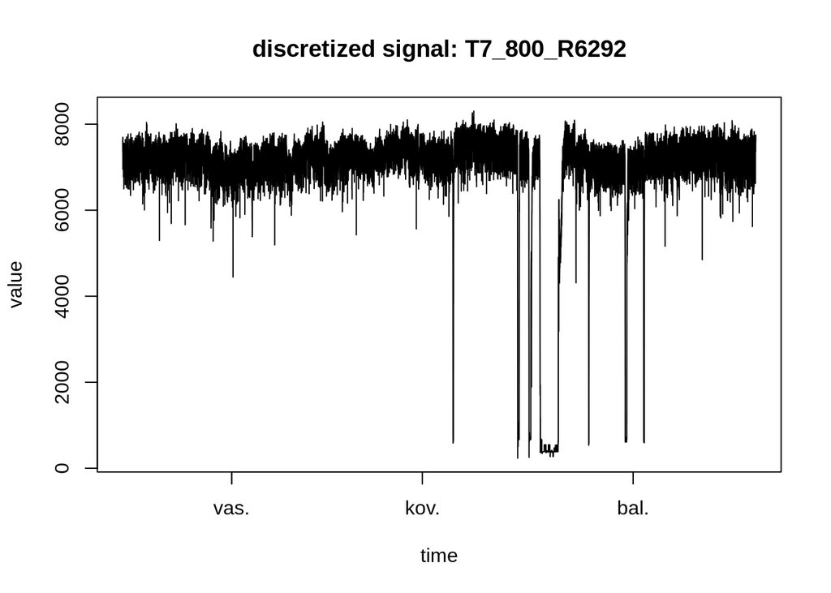

```
## [1] "Only one graph showed because same sensor chosen"
## First signal subset:  2019-02-16 14:55:00 - 2019-02-16 19:50:00
```

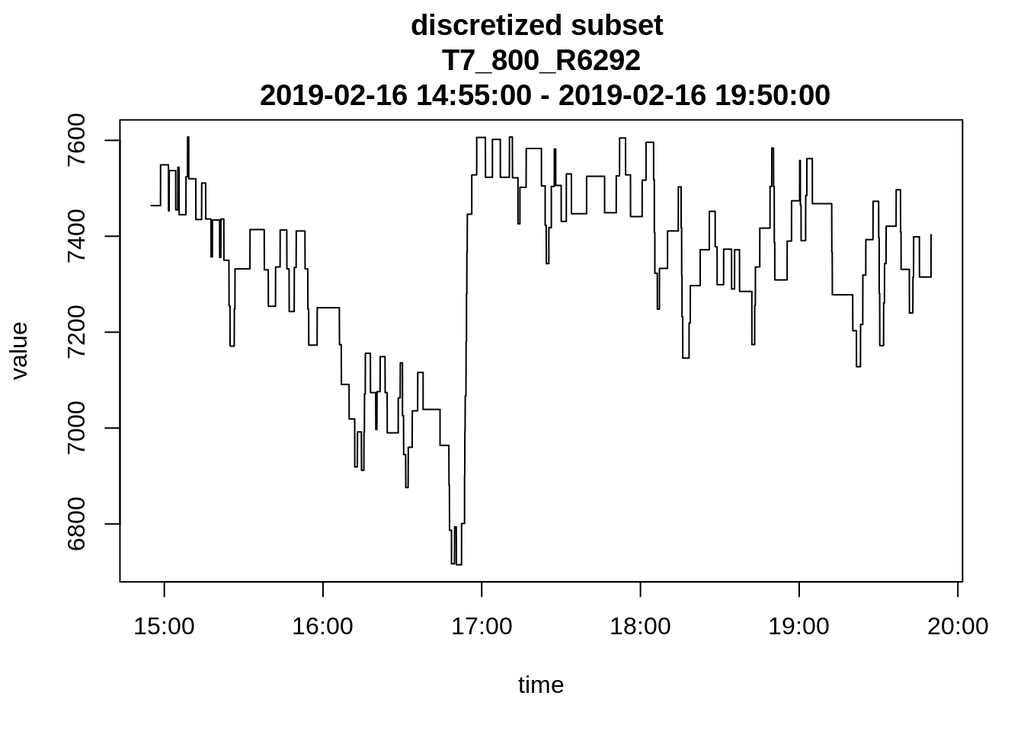

```
## Second signal subset:  2019-02-16 19:50:00 - 2019-02-17 01:02:00
```

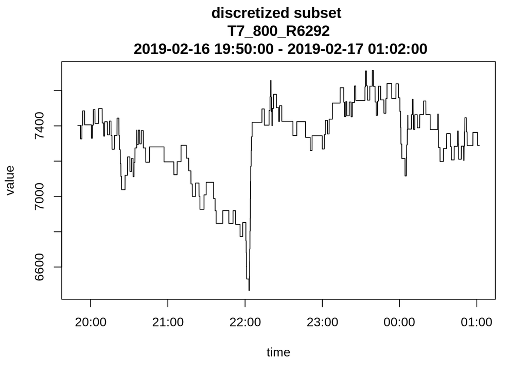

## Auto-correlation

**Auto correlation** is the correlation of a time series with its own past and future values  
if data is strongly seasonal - peaks will apear with seasonality period  
**Partial autocorrelation** at lag k is the correlation that results after removing the effect of any correlations due to the terms at shorter lags

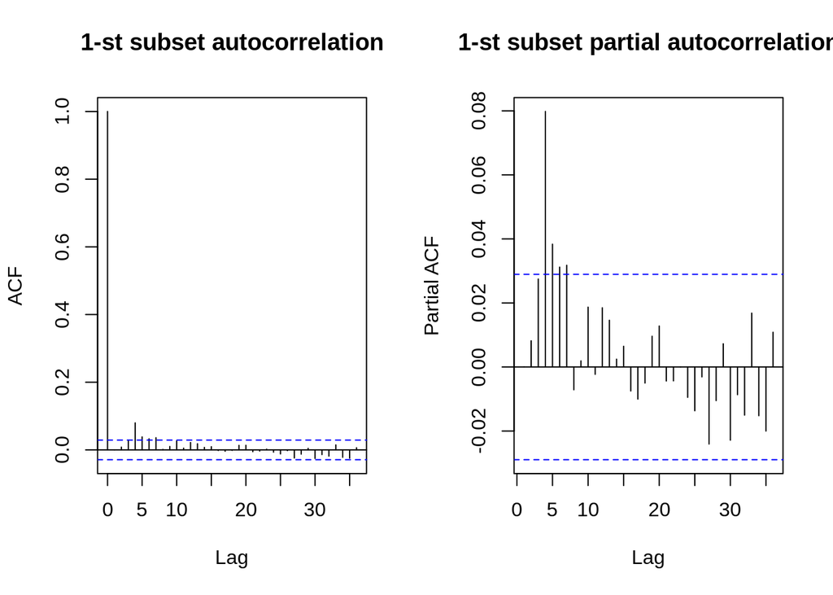

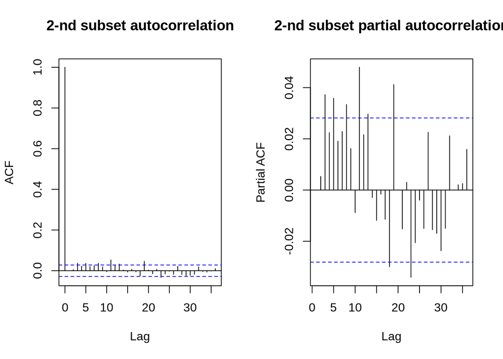

## Generalized Additive Model

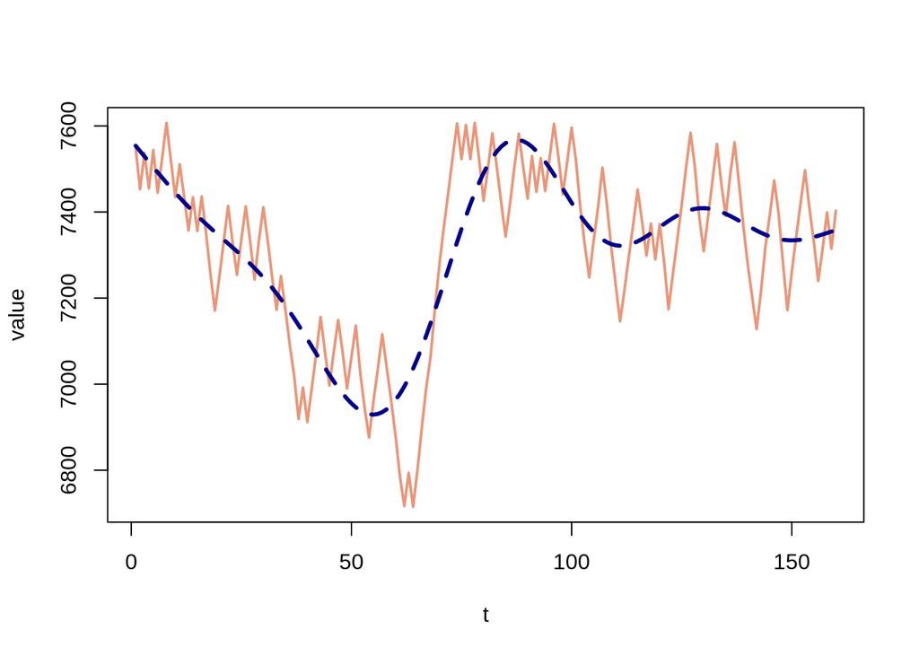

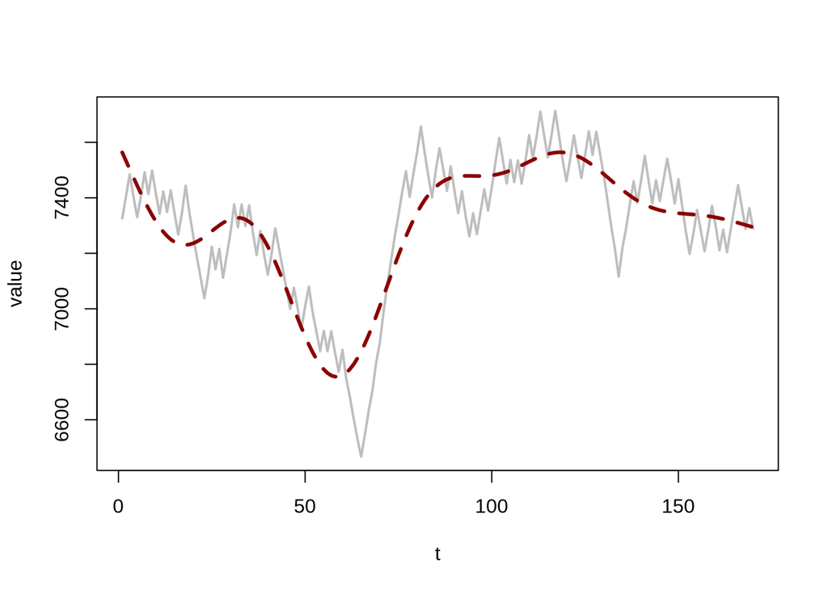

Generalized additive model formula:

- $g(E(Y)) = \beta_{0} + f_{1}(x_{1}) + f_{2}(x_{2}) + \cdots + f_{m}(x_{m}) + \varepsilon$
- $x_{1}, x_{2}, \dots, x_{m}$ - are independent variables
- $\beta_{0}$ - is an intercept
- $f_{1}, f_{2}, \dots, f_{m}$ - are unknow smooth functions (splines)
- $\epsilon$ - is an random error

Generalized additive method coefficients

|  | model.coefficients | model2.coefficients |
| --- | --- | --- |
| (Intercept) | 7311 | 7301 |
| s(t).1 | -420 | -741 |
| s(t).2 | 630 | 900 |
| s(t).3 | -303 | -526 |
| s(t).4 | 272 | 214 |
| s(t).5 | -53 | 72 |
| s(t).6 | -568 | -1011 |
| s(t).7 | 156 | -307 |
| s(t).8 | -734 | -1501 |
| s(t).9 | -208 | -839 |

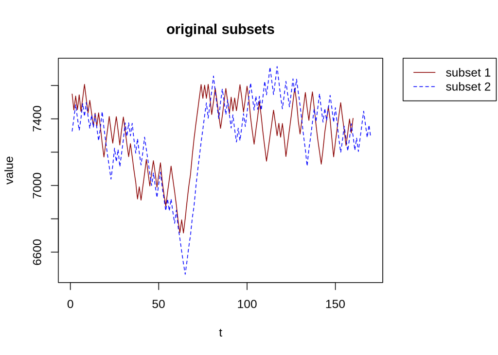

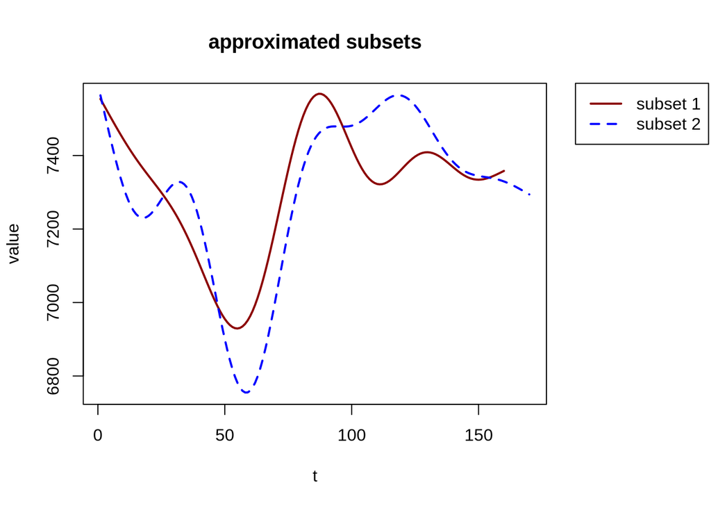

**Correlation between approximated signals**

```
## [1] 0.8334519
```

We can make further predictions based on this models.